# Guilds Project Code

## 1. Data pre-process and exploration (EDA)

Summary of Part 1: In this part, we firstly checked and tried to understand the structure of the data frame. Secondly, we checked and processed binary variables and missing values based on differenct situations. Thridly, we did the EDA to visualize the data frame and tried to find the correlation between variables, which was helpful to build the model

### 1.1 Understand the data structure

```python
import pandas as pd
import numpy as np
import matplotlib.pyplot as plt
import seaborn as sns
import os
import missingno as msno
import matplotlib.pyplot as plt

# set working directory
# os.chdir('/Users/os/Documents/python/Final Program-guilds')
sns.set_style("whitegrid")
```

```python
# load data
file_path = 'guilds.csv'
df = pd.read_csv(file_path)
```

Here we could see all variables and their types as following.

```python
# read data in total
df.info()
df.describe().T

numeric_columns = df.select_dtypes(include="float64").columns
```

```
<class 'pandas.core.frame.DataFrame'>
RangeIndex: 253680 entries, 0 to 253679
Data columns (total 31 columns):
 #   Column                               Non-Null Count   Dtype
---  ------                               --------------   -----
 0   Fae_Dust_Reserve                     228327 non-null  float64
 1   Physical_Stamina                     228269 non-null  float64
 2   Mystical_Index                       228480 non-null  float64
 3   Healer_consultation_Presence         228348 non-null  object
 4   Elixir_veggies_consumption_Presence  228110 non-null  object
 5   Mystic_Energy_Level                  228177 non-null  float64
 6   Bolt_of_doom_Presence                228146 non-null  object
 7   Age_of_Wisdom                        228309 non-null  float64
 8   High_willingness_Presence            228370 non-null  object
 9   Defense_spell_difficulty_Presence    228385 non-null  object
```

[output cut: 23 more lines]

Here we counted missing values and visualized them.

```python
# count Nah
nan_count= df.isna().sum()
print("NaN count in each column:")
print(nan_count)
```

```
NaN count in each column:
Fae_Dust_Reserve                       25353
Physical_Stamina                       25411
Mystical_Index                         25200
Healer_consultation_Presence           25332
Elixir_veggies_consumption_Presence    25570
Mystic_Energy_Level                    25503
Bolt_of_doom_Presence                  25534
Age_of_Wisdom                          25371
High_willingness_Presence              25310
Defense_spell_difficulty_Presence      25295
Doc_availability_challenge_Presence    25447
Mental_Wizardry                        25414
Potion_Power_Level                     25439
Dexterity_check_Presence               25043
Gold_Pouches_Per_Year                  25313
Wizardry_Skill                         25266
Spell_Mastering_Days                   25204
Level_of_Academic_Wisdom               25560
General_Health_Condition               25569
Fruits_of_eden_consumption_Presence    25229
Knight_physical_training_Presence      25459
Royal_family_pressure_Presence         25505
Dragon_Sight_Sharpness                 25539
Guild_Membership                       25447
Enchanted_Coin_Count                   25531
Celestial_Alignment                    25673
Knightly_Valor                         25502
Heavy_elixir_consumption_Presence      25410
Stigmata_of_the_cursed_Presence        25155
Dragon_status_Presence                 25661
Rune_Power                             25266
dtype: int64
```

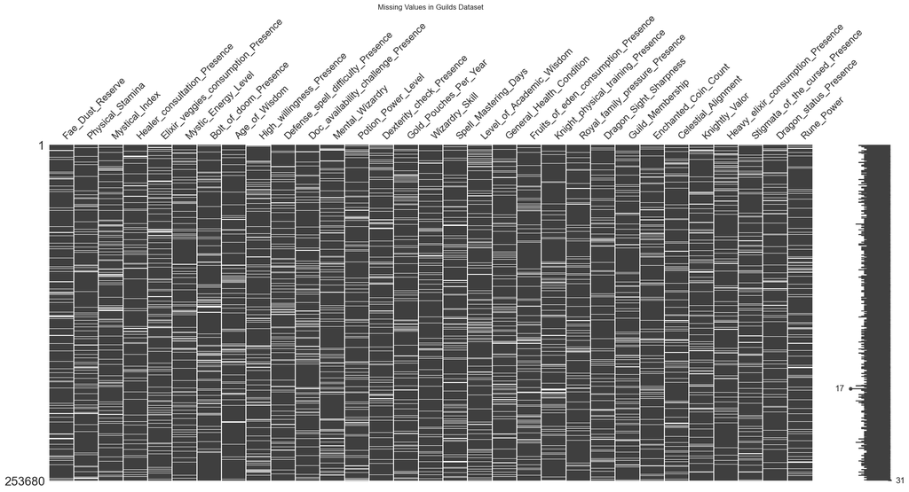

```python
# Visualize missing values using missingno
plt.figure(figsize=(12, 6))
msno.matrix(df)
plt.title("Missing Values in Guilds Dataset")
plt.show()
```

Then, we tried to pre-process the data based on different types of variables.

```python
df.head()
```

|  | Fae_Dust_Reserve | Physical_Stamina | Mystical_Index | Healer_consultation_Presence | Elixir_veggies_consumption_Presence | Mystic_Energy_Level | Bolt_of_doom_Presence | Age_of_Wisdom | High_willingness_Presence | Defense_spell_difficulty_Presence | ... | Royal_family_pressure_Presence | Dragon_Sight_Sharpness | Guild_Membership | Enchanted_Coin_Count | Celestial_Alignment | Knightly_Valor | Heavy_elixir_consumption_Presence | Stigmata_of_the_cursed_Presence | Dragon_status_Presence | Rune_Power |
| --- | --- | --- | --- | --- | --- | --- | --- | --- | --- | --- | --- | --- | --- | --- | --- | --- | --- | --- | --- | --- | --- |
| 0 | 7.129337 | 0.0 | 28.0 | Present | Absent | 0.855643 | Absent | 8.0 | Present | Absent | ... | Present | 5.0 | Master_Guild | 394.0 | 6.093753 | 4.0 | Absent | Absent | Present | NaN |
| 1 | 5.465800 | 4.0 | 37.0 | Present | Present | 0.628994 | Absent | 11.0 | Present | Absent | ... | Present | 9.0 | Master_Guild | NaN | 3.872185 | NaN | Absent | NaN | Absent | 42.647811 |
| 2 | 4.464708 | 0.0 | 41.0 | Present | Present | NaN | Absent | 9.0 | Present | Absent | ... | NaN | 3.0 | No_Guild | 421.0 | 4.300012 | 6.0 | Absent | Absent | Present | 32.426926 |
| 3 | 8.214439 | 0.0 | 30.0 | Present | Present | 1.766648 | Absent | 10.0 | Absent | Absent | ... | Absent | 3.0 | No_Guild | 321.0 | 7.294827 | 4.0 | Absent | Absent | Present | 9.311121 |
| 4 | 9.479264 | 0.0 | 49.0 | Present | Present | NaN | Absent | NaN | Absent | Absent | ... | Present | NaN | No_Guild | 268.0 | NaN | 5.0 | Absent | Absent | Absent | 14.979970 |

5 rows × 31 columns

### 1.2 Data Pre-processing

For binary variables, we convert them to dummy variables, which is convenient for later usages.

```python
binary_columns = df.filter(like='Presence').columns  # list of binary variables

# convert and replace to dummy variables
for col in binary_columns:
    df[col] = df[col].map({'Present': 1, 'Absent': 0})  # replace
# result
print(df[binary_columns])
```

```
        Healer_consultation_Presence  Elixir_veggies_consumption_Presence  \
0                                1.0                                  0.0
1                                1.0                                  1.0
2                                1.0                                  1.0
3                                1.0                                  1.0
4                                1.0                                  1.0
...                              ...                                  ...
253675                           1.0                                  1.0
253676                           1.0                                  0.0
253677                           1.0                                  1.0
253678                           1.0                                  1.0
253679                           1.0                                  1.0

        Bolt_of_doom_Presence  High_willingness_Presence  \
0                         0.0                        1.0
```

[output cut: 90 more lines]

For missing values, we processed them by three ways, based on different situations (e.g. the exact meaning of the variable)

1). For missing values in each binary column, we filled them with the mode of that column. This is because the mode of the column represents the most frequent category of this variable. We believed most indivisuals share the same probability of the situation, and hence, they are more likely to be in the category with the mode.

2). For missing values in each numeric column, we filled them with the mean of that column. This is because the mean of the column represents the sample mean of this variable. According to the e large number low, we believe that the sample mean would converge to the popular mean. Hence, we use the sample mean as a moderate number to fill the missing value.

3). For missing values in the "Guild_Memberiship" column, which is our dependent variable and represents the guild of each membership. It may be not suitable to fill it with any imputation method, because it is the target of our models. Moreover, we have enough large data points. Therefore, we dropped oberservations without the value of Guild_Membership.

```python
# Fill NaN values in each binary column with the mode (most frequent value) of that column
df.update(df[binary_columns].apply(lambda x: x.fillna(x.mode()[0])))

# Fill NaN values in each numeric column with the mean (average) of that column
df.update(df[numeric_columns].apply(lambda x: x.fillna(x.mean())))

# Drop NaN values in the 'Guild_Membership' column
df = df.dropna(subset=['Guild_Membership'])

# Calculate the number of NaN values in each column and store in 'nan_count'
nan_count = df.isna().sum()
print("NaN count in each column:")
print(nan_count)
```

```
NaN count in each column:
Fae_Dust_Reserve                       0
Physical_Stamina                       0
Mystical_Index                         0
Healer_consultation_Presence           0
Elixir_veggies_consumption_Presence    0
Mystic_Energy_Level                    0
Bolt_of_doom_Presence                  0
Age_of_Wisdom                          0
High_willingness_Presence              0
Defense_spell_difficulty_Presence      0
Doc_availability_challenge_Presence    0
Mental_Wizardry                        0
Potion_Power_Level                     0
Dexterity_check_Presence               0
Gold_Pouches_Per_Year                  0
Wizardry_Skill                         0
Spell_Mastering_Days                   0
Level_of_Academic_Wisdom               0
General_Health_Condition               0
Fruits_of_eden_consumption_Presence    0
Knight_physical_training_Presence      0
Royal_family_pressure_Presence         0
Dragon_Sight_Sharpness                 0
Guild_Membership                       0
Enchanted_Coin_Count                   0
Celestial_Alignment                    0
Knightly_Valor                         0
Heavy_elixir_consumption_Presence      0
Stigmata_of_the_cursed_Presence        0
Dragon_status_Presence                 0
Rune_Power                             0
dtype: int64
```

Here, we counted the numbers of different Guild_Memberships. We find that this is a imbalanced dataset, the oberservations with "Apprentice_Guild" and "Master_Guild" are sparse. We may pay more attention to train the performance of the model in different categories, using methods like oversampling or putting weights.

```python
df['Guild_Membership'].value_counts()
```

```
Guild_Membership
No_Guild            192328
Master_Guild         31739
Apprentice_Guild      4166
Name: count, dtype: int64
```

For convenience and consistence, we outputed the file of processed data. We use the processed data for building model more easily.

```python
output_path = 'processed_guilds.csv'
df.to_csv(output_path, index=False)

output_path
#Save cleaned dataset independently for further analysis
```

```
'processed_guilds.csv'
```

### 1.3 Exploratory Data Analysis

We firstly plotted the distributions of each variable to help understand all variables and data structure.

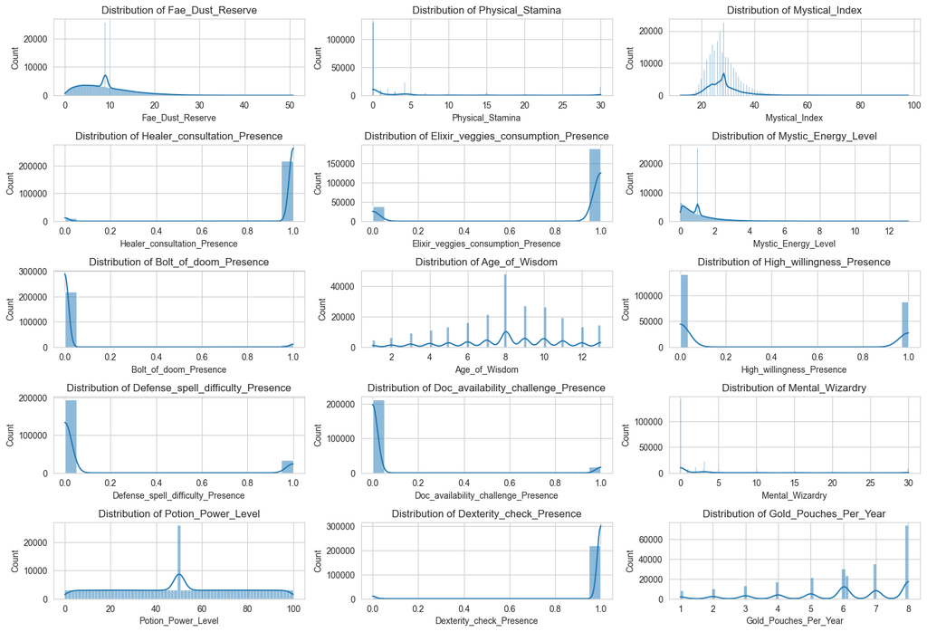

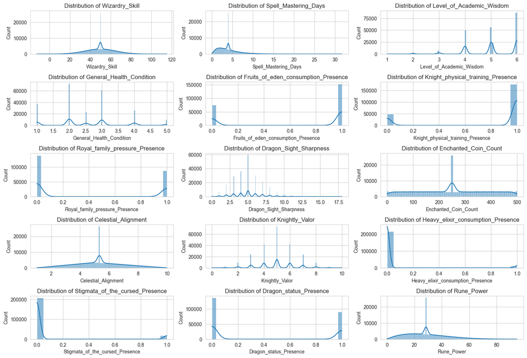

```python
# Visualizing distributions of main features
numeric_columns = df.select_dtypes(include=[np.number]).columns.tolist()

# Batch size for subplots
batch_size = 15

# Loop through columns in batches
for start in range(0, len(numeric_columns), batch_size):
    plt.figure(figsize=(15, 30))
    columns_batch = numeric_columns[start:start + batch_size]
    for i, col in enumerate(columns_batch, 1):
        plt.subplot(len(columns_batch), 3, i)
        sns.histplot(df[col].dropna(), kde=True)  # Plotting histogram with KDE
        plt.title(f'Distribution of {col}')
    plt.tight_layout()
    plt.show()
```

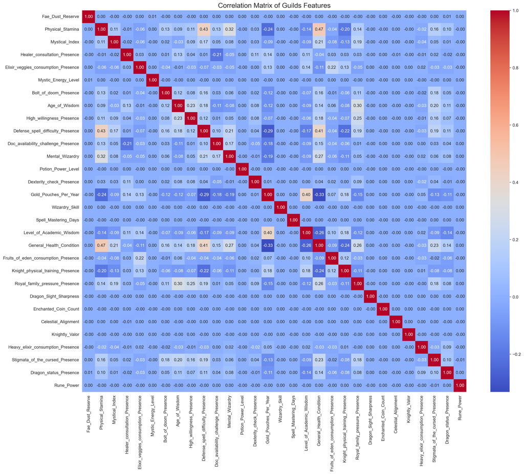

```python
# Correlation matrix for numeric columns
correlation_matrix = df[numeric_columns].corr()  # Compute correlation matrix
plt.figure(figsize=(20, 16), dpi=200)
sns.heatmap(correlation_matrix, annot=True, cmap='coolwarm', fmt='.2f')
plt.title('Correlation Matrix of Guilds Features', fontsize=16)
plt.show()
```

## 2. Baseline Model: Logit Regression

Summary of Part 2: Here, I selected logit regression as our baseline model for several reasons.

1). Simplicity. This model is simple and easy to be built.

2). Popularity. This model is widely used in classification problem.

Since there are three values in our target variable, hence here we have a multiple classification problem. For logit in multiple regression, I chose mlogit model since there is no order in the values of target variable. I firstly loaded the data and defined the independent and dependent variables. Then, I used forward selection to extract the most correlated and useful variables for the classification with AIC as the criterion. Then I trained the model and tested in a different test set. Finally, I ouputed the confusion matrix and the classification report to manifest the performance of the model, with the plot visualized weights of different independent variables to help better understand the model.

### 2.1 Data Loading and Forward Selection

Here, I loaded the data firstly.

```python
import pandas as pd
import numpy as np
from sklearn.model_selection import train_test_split
from sklearn.linear_model import LogisticRegression
from sklearn.preprocessing import StandardScaler
from sklearn.metrics import confusion_matrix, classification_report
from imblearn.over_sampling import SMOTE
import statsmodels.api as sm
import matplotlib.pyplot as plt

# Step 1: load data
df = pd.read_csv('processed_guilds.csv')
X = df.drop(columns=['Guild_Membership'])  # features
y = df['Guild_Membership']  # target variables
```

Then, because there are too many variables, I used forward selection with AIC as the criterion to select the most useful features for building the model.

```python
# Step 2: forward selection
def forward_selection(X, y):
    initial_features = []
    remaining_features = list(X.columns)
    selected_features = []
    while remaining_features:
        scores = {}
        for feature in remaining_features:
            try:
                model = sm.Logit(pd.get_dummies(y, drop_first=True), sm.add_constant(X[initial_features + [feature]])).fit(disp=False)
                scores[feature] = model.aic
            except:
                scores[feature] = float('inf')
        best_feature = min(scores, key=scores.get)
        if selected_features and scores[best_feature] > scores[selected_features[-1]]:
            break
        initial_features.append(best_feature)
        remaining_features.remove(best_feature)
    return initial_features

# processing forward selection
selected_features = forward_selection(X, y)
```

### 2.1 Split the Dataset and Train the Model

Then, I extracted the data with selected features and dependent variables. I splitted them into test set and trainning set with a ratio of 1:9. Here I used stratified sampling to ensure the same size of each category.

```python
# Step 3: split the data
X_train, X_test, y_train, y_test = train_test_split(X[selected_features], y, test_size=0.1, random_state=42, stratify=y)
```

Then, I standardized all indenpendent variables to uniform the scales.

```python
# Step 5: Data standardize
scaler = StandardScaler()
X_train_scaled = scaler.fit_transform(X_train)
X_test_scaled = scaler.transform(X_test)
```

I trained the model with "class_weight='balanced", max_iter=8000".

The first parameter was to reduce the bias by imbalaced data structure. The second parameter was to make the model achieve convergence.

```python
# Step 6: Train the model
mlogit = LogisticRegression(class_weight='balanced', max_iter=8000)
mlogit.fit(X_train_scaled, y_train)
```

```
LogisticRegression(class_weight='balanced', max_iter=8000)
```

### 2.3 Test and Assess the Model Performance

Finally, I tested the logit model on test set and ouputed the confusion matrix and classification report.

The performance is not ideal. The ouput told us the model performs better in predicting "No_Guild" but worse in "Apprentice_Guild" and "Master_Guild". The test accuracy is 0.65.

```python
# Step 7: Test the model
y_pred = mlogit.predict(X_test_scaled)

# Confusion matric
print("Confusion Matrix:")
conf_matrix = confusion_matrix(y_test, y_pred)
print(conf_matrix)

# Classification Report
print("\nClassification Report:")
print(classification_report(y_test, y_pred))
```

```
Confusion Matrix:
[[  129   157   131]
 [  792  1815   567]
 [ 3200  3237 12796]]

Classification Report:
                  precision    recall  f1-score   support

Apprentice_Guild       0.03      0.31      0.06       417
    Master_Guild       0.35      0.57      0.43      3174
        No_Guild       0.95      0.67      0.78     19233

        accuracy                           0.65     22824
       macro avg       0.44      0.52      0.42     22824
    weighted avg       0.85      0.65      0.72     22824
```

The plot shows the coefficients of each feature used in the logit model to visulaize the weight of different variables.

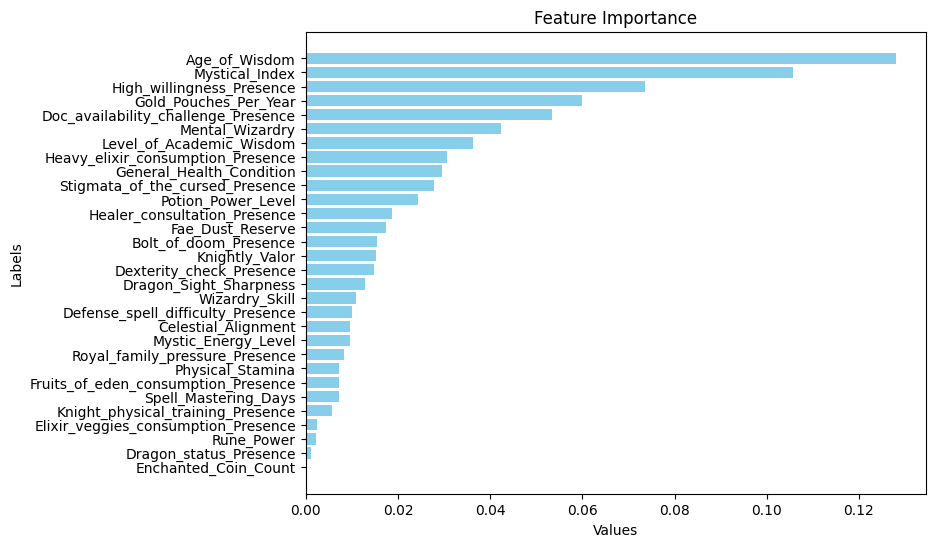

```python
coefficients = np.abs(mlogit.coef_[0])
feature_names = X.columns
coef_importance = list(zip(feature_names, coefficients))
coef_importance.sort(key=lambda x: x[1], reverse=True)

labels, values = zip(*coef_importance)
plt.figure(figsize=(8, 6))
plt.barh(labels, values, color='skyblue')
plt.xlabel('Values')
plt.ylabel('Labels')
plt.title('Feature Importance')
plt.gca().invert_yaxis()  # Invert the y-axis to display the top feature at the top
plt.show()
```

## 3. Model Attemptation

As we saw above, the performance of logit model is not satified. Hence we tried 2 more models, one is t**Random Forest Classifer**, and the other is **Convolutional Nerual Network**. We trained and assessed them respectively as following.

### 3.1 Random Forest Classifer

**Why Use Random Forest**

Random Forest is an ensemble learning method known for its robustness and accuracy in classification tasks. It is particularly effective for datasets with complex patterns and a mix of binary or categorical variables, like our guild membership dataset.

Key reasons for using Random Forest:

1. Handling Imbalanced Data: Random Forest handles imbalanced datasets well by adjusting class weights or by balancing bootstrapped samples.
2. Feature Importance: It provides feature importance scores, allowing for better understanding of the influential features in decision-making.
3. Non-linearity: Random Forest can capture non-linear relationships between features, which is beneficial for datasets with complex attribute interactions.

**Implementation**

First, I imported necessary libraries, loaded the dataset, and split it into features (X) and target (y). I chose to use Scikit-learn for its simplicity and efficient implementation of Random Forest.

```
import pandas as pd
import numpy as np
from sklearn.model_selection import train_test_split
from sklearn.preprocessing import LabelEncoder
from sklearn.ensemble import RandomForestClassifier
from sklearn.metrics import classification_report, confusion_matrix, accuracy_score
```

Step 1: Load the Dataset

The dataset processed_guilds.csv is read, and the target variable (Guild_Membership) is separated from the features.

```
df = pd.read_csv('processed_guilds.csv')
X = df.drop(columns=['Guild_Membership'])
y = df['Guild_Membership']
```

Step 2: Encode Target Variable & Split Data

The target variable (y) is label-encoded into numerical values for compatibility with Scikit-learn. The dataset is split into training (80%) and test (20%) sets.

```
encoder = LabelEncoder()
y_encoded = encoder.fit_transform(y)

X_train, X_test, y_train, y_test = train_test_split(X, y_encoded, test_size=0.2, random_state=42, stratify=y_encoded)
```

Step 3: Model Initialization

The Random Forest Classifier is initialized with hyperparameters that balance performance and prevent overfitting: • n_estimators=100: Use 100 trees in the forest. • max_depth=None: Allow trees to expand until all leaves are pure. • class_weight='balanced': Handle the imbalanced dataset by weighting classes inversely proportional to their frequency.

```
rf_model = RandomForestClassifier(
    n_estimators=100,
    random_state=42,
    class_weight='balanced'
)
```

Step 4: Model Training

The model is trained using the fit method on the training set.

```
rf_model.fit(X_train, y_train)
```

Step 5: Predictions & Evaluation

After training, predictions are made on the test set. The performance is evaluated using: • Accuracy Score: Overall classification accuracy. • Confusion Matrix: Provides insight into class-wise predictions. • Classification Report: Displays precision, recall, and F1-score for each class.

```
y_pred = rf_model.predict(X_test)

print("Test Accuracy:", accuracy_score(y_test, y_pred))
print("\nConfusion Matrix:\n", confusion_matrix(y_test, y_pred))
print("\nClassification Report:\n", classification_report(y_test, y_pred, target_names=encoder.classes_))
```

**Model Results and Interpretation**

**Conclusion**

Random Forest achieved promising results on the guild classification task. However:

- Imbalanced data affects minority class performance. Strategies like oversampling, undersampling, or SMOTE can further improve results.
- Feature engineering or different hyperparameter tuning may also improve Apprentice_Guild prediction accuracy.

```
Fitting 2 folds for each of 216 candidates, totalling 432 fits
Best hyperparameters: {'max_depth': 30, 'max_features': 'log2', 'min_samples_leaf': 2, 'min_samples_split': 10, 'n_estimators': 200}
Optimized model performance:
                  precision    recall  f1-score   support

Apprentice_Guild       0.00      0.00      0.00       833
    Master_Guild       0.45      0.37      0.40      6348
        No_Guild       0.89      0.93      0.91     38466

        accuracy                           0.84     45647
       macro avg       0.45      0.43      0.44     45647
    weighted avg       0.81      0.84      0.82     45647
```

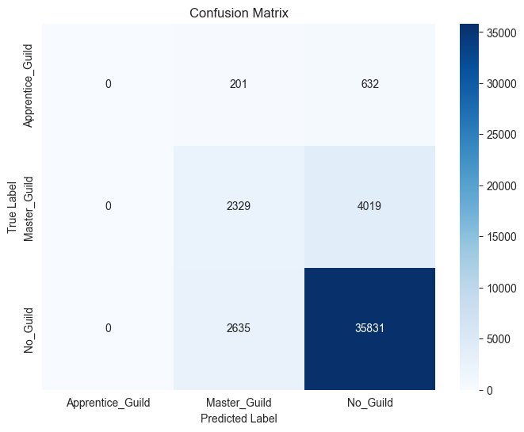

```python
# Import necessary libraries
import pandas as pd
from sklearn.model_selection import train_test_split, GridSearchCV
from sklearn.ensemble import RandomForestClassifier
from sklearn.metrics import classification_report, confusion_matrix
import matplotlib.pyplot as plt
import seaborn as sns
from sklearn.preprocessing import LabelEncoder
import warnings
warnings.filterwarnings("ignore")
# The data is already preprocessed, 'Guild_Membership' is the target variable

df = pd.read_csv('processed_guilds.csv')
# Separate features and target
X = df.drop(columns=['Guild_Membership'])
y = df['Guild_Membership']

# Encode the target variable into numeric values
label_encoder = LabelEncoder()
y_encoded = label_encoder.fit_transform(y)

# Split the dataset into training and validation sets
X_train, X_val, y_train, y_val = train_test_split(
    X, y_encoded, test_size=0.2, random_state=42, stratify=y_encoded
)

# Define the Random Forest classifier
rf = RandomForestClassifier(random_state=42, class_weight='balanced')

# Set the parameter grid for hyperparameter tuning
param_grid = {
    'n_estimators': [100, 200],
    'max_depth': [10, 20, 30, None],
    'min_samples_split': [2, 5, 10],
    'min_samples_leaf': [1, 2, 4],
    'max_features': ['sqrt', 'log2', None]
}

# Perform hyperparameter tuning using GridSearchCV
grid_search = GridSearchCV(
    estimator=rf,
    param_grid=param_grid,
    scoring='f1_weighted',  # Use weighted F1 score as the evaluation metric
    cv=2,  # 2-fold cross-validation
    verbose=2,
    n_jobs=-1  # Use all available CPU cores
)

# Run the hyperparameter search
grid_search.fit(X_train, y_train)

# Retrieve the best parameters
best_params = grid_search.best_params_
print("Best hyperparameters:", best_params)

# Train the final model with the best parameters
best_rf = grid_search.best_estimator_
best_rf.fit(X_train, y_train)

# Make predictions on the validation set
y_pred = best_rf.predict(X_val)

# Decode the predicted and true labels
y_val_labels = label_encoder.inverse_transform(y_val)
y_pred_labels = label_encoder.inverse_transform(y_pred)

# Generate the classification report
print("Optimized model performance:")
print(classification_report(y_val_labels, y_pred_labels, target_names=label_encoder.classes_))

# Plot the confusion matrix
conf_matrix = confusion_matrix(y_val_labels, y_pred_labels, labels=label_encoder.classes_)
plt.figure(figsize=(8, 6))
sns.heatmap(conf_matrix, annot=True, fmt='d', cmap='Blues',
            xticklabels=label_encoder.classes_,
            yticklabels=label_encoder.classes_)
plt.title('Confusion Matrix')
plt.xlabel('Predicted Label')
plt.ylabel('True Label')
plt.show()
```

### 3.2 Convolutional Nerual Network (CNN)

Why to use CNN:

1. It is expected that CNN will capture local dependencies and patterns between neighboring features, potentially improving performance.
2. It is expected that the complex relationships in a large dataset may be better caputered by CNN.

#### 3.2.1 Prepare for CNN Model

Here is the preparation for the CNN model.

Firstly, I loaded the necessary packages and datset, and I defined the independent and dependent variables.

Here, I used PyTorch instead of tensorflow, because I am more familiar with PyTorch and it is simplier in building a CNN model.

```python
import pandas as pd
import numpy as np
import torch
import torch.nn as nn
import torch.optim as optim
from sklearn.model_selection import train_test_split
from sklearn.preprocessing import StandardScaler, LabelEncoder
from torch.utils.data import DataLoader, TensorDataset
from sklearn.metrics import confusion_matrix, classification_report
import matplotlib.pyplot as plt

# Step 1: Load dataset
df = pd.read_csv('processed_guilds.csv')  # Replace with your actual file path
X = df.drop(columns=['Guild_Membership']).values  # Features
y = df['Guild_Membership']  # Target variable
```

The cell following is to encode the dependent variables and split the dataset into trainning set, validation set and test set with a typical ratio of 8:1:1.

The training set and validation set are used to train and validate the model during training process, and the test set is only used in testing and assessing the model performance.

```python
# Step 2: Encode target labels
encoder = LabelEncoder()
y_encoded = encoder.fit_transform(y)  # Convert target labels to integers

# Step 3: Split data into training (80%) and temp (20%)
X_train, X_temp, y_train, y_temp = train_test_split(
    X, y_encoded, test_size=0.2, random_state=42, stratify=y_encoded
)

# Step 4: Split temp into validation (50% of temp) and test (50% of temp)
X_val, X_test, y_val, y_test = train_test_split(
    X_temp, y_temp, test_size=0.5, random_state=42, stratify=y_temp
)

# Print class distribution
print("Class distribution in training set:", dict(zip(*np.unique(y_train, return_counts=True))))
print("Class distribution in validation set:", dict(zip(*np.unique(y_val, return_counts=True))))
print("Class distribution in test set:", dict(zip(*np.unique(y_test, return_counts=True))))
```

```
Class distribution in training set: {np.int64(0): np.int64(3333), np.int64(1): np.int64(25391), np.int64(2): np.int64(153862)}
Class distribution in validation set: {np.int64(0): np.int64(416), np.int64(1): np.int64(3174), np.int64(2): np.int64(19233)}
Class distribution in test set: {np.int64(0): np.int64(417), np.int64(1): np.int64(3174), np.int64(2): np.int64(19233)}
```

The cell following is to standardize all input features and to convert all variables into tensors, and setup data loader.

For standardization, CNN models often perform better when input features are standardized (scaled to have a mean of 0 and a standard deviation of 1).

For converting to PyTorch tensors, it is required by PyTorch models for the data to be in the form of tensors.Inputs (X_train_scaled, etc.) are converted to tensors using torch.tensor.Outputs (y_train, etc.) are also converted to tensors, but without adding dimension.

For dataloader setup, it is used to manage data batches and feed them efficiently to the model.

```python
# Step 5: Standardize features
scaler = StandardScaler()
X_train_scaled = scaler.fit_transform(X_train)  # Fit on training set
X_val_scaled = scaler.transform(X_val)  # Transform validation set
X_test_scaled = scaler.transform(X_test)  # Transform test set

# Convert to PyTorch tensors
X_train_tensor = torch.tensor(X_train_scaled, dtype=torch.float32).unsqueeze(1)
X_val_tensor = torch.tensor(X_val_scaled, dtype=torch.float32).unsqueeze(1)
X_test_tensor = torch.tensor(X_test_scaled, dtype=torch.float32).unsqueeze(1)
y_train_tensor = torch.tensor(y_train, dtype=torch.long)
y_val_tensor = torch.tensor(y_val, dtype=torch.long)
y_test_tensor = torch.tensor(y_test, dtype=torch.long)

# DataLoader
train_loader = DataLoader(TensorDataset(X_train_tensor, y_train_tensor), batch_size=64, shuffle=True)
val_loader = DataLoader(TensorDataset(X_val_tensor, y_val_tensor), batch_size=64, shuffle=False)
test_loader = DataLoader(TensorDataset(X_test_tensor, y_test_tensor), batch_size=64, shuffle=False)
```

#### 3.2.2 Build CNN Model

The cell following is to build a CNN model with a typical structure.

1. Convolution + Activation + BatchNorm + Pooling
2. Flatten
3. Dropout and Fully Connected Layers

```python
class EnhancedCNN(nn.Module):
    def __init__(self, input_dim, num_classes):
        super(EnhancedCNN, self).__init__()
        self.conv1 = nn.Conv1d(1, 64, kernel_size=5, stride=1, padding=2)
        self.bn1 = nn.BatchNorm1d(64)
        self.pool1 = nn.MaxPool1d(2)

        self.conv2 = nn.Conv1d(64, 128, kernel_size=3, stride=1, padding=1)
        self.bn2 = nn.BatchNorm1d(128)
        self.pool2 = nn.MaxPool1d(2)

        self.conv3 = nn.Conv1d(128, 256, kernel_size=3, stride=1, padding=1)
        self.bn3 = nn.BatchNorm1d(256)
        self.pool3 = nn.MaxPool1d(2)

        self.dropout = nn.Dropout(0.5)  # Reduce overfitting

        # Dynamically calculate flattened dimension after 3 pooling layers
        flattened_dim = (input_dim // (2 ** 3)) * 256
        if flattened_dim <= 0:
            raise ValueError(f"Invalid flattened dimension: {flattened_dim}. Check input dimensions and pooling layers.")

        self.fc1 = nn.Linear(flattened_dim, 256)
        self.fc2 = nn.Linear(256, num_classes)

    def forward(self, x):
        x = torch.relu(self.bn1(self.conv1(x)))
        x = self.pool1(x)

        x = torch.relu(self.bn2(self.conv2(x)))
        x = self.pool2(x)

        x = torch.relu(self.bn3(self.conv3(x)))
        x = self.pool3(x)

        x = x.view(x.size(0), -1)  # Flatten
        x = self.dropout(torch.relu(self.fc1(x)))
        x = self.fc2(x)
        return x
```

This code following sets up the device, model, loss function, and optimizer for training a neural network in PyTorch.

1. Device: Set GPUs for a faster computation.
2. Model: Initialize the CNN model with input dimensions and class count. Use multiple GPUs.
3. Loss: Use weighted cross-entropy loss to handle imbalanced classes.
4. Optimizer: Use Adam with L2 regularization to optimize the model's parameters.
5. Scheduler: Automatically adjust the learning rate to improve convergence.

```python
# Step 7: Initialize device and model
device = torch.device("cuda" if torch.cuda.is_available() else "cpu")  # Use GPU if available
print(f"Using device: {device}")

input_dim = X_train_scaled.shape[1]
num_classes = len(encoder.classes_)

# Define the CNN model
model = EnhancedCNN(input_dim=input_dim, num_classes=num_classes)

# Wrap the model to utilize all available GPUs
if torch.cuda.device_count() > 1:
    print(f"Using {torch.cuda.device_count()} GPUs.")
    model = nn.DataParallel(model)  # DataParallel distributes the model across all GPUs

# Move the model to the main device
model = model.to(device)

# Step 8: Define loss function and optimizer
class_weights = torch.tensor(1.0 / np.bincount(y_train), dtype=torch.float32).to(device)
criterion = nn.CrossEntropyLoss(weight=class_weights)

# Use Adam optimizer with L2 regularization
optimizer = optim.Adam(model.parameters(), lr=0.0005, weight_decay=1e-3)

# Add learning rate scheduler
from torch.optim.lr_scheduler import ReduceLROnPlateau
scheduler = ReduceLROnPlateau(optimizer, mode='min', factor=0.1, patience=6)  # Adjust patience for scheduler
```

```
Using device: cuda
Using 8 GPUs.
```

#### 3.2.3 Train CNN Model

The cell following trains the model using the training and validation datasets while monitoring performance metrics. Here are some special points:

1. After each epoch, training and validation metrics are displayed, which is useful for us to monitoring the training process of the model.
2. The learning rate scheduler (scheduler) dynamically reduces the learning rate if the validation loss doesn’t improve, which is helpful to achieve better model performance.
3. Early Stopping: If validation loss improves, the patience counter resets.If validation loss doesn’t improve for 6 consecutive epochs, training stops early.

```python
# Step 9: Train the model
epochs = 60
patience = 6
best_val_loss = float('inf')
patience_counter = 0

train_losses, val_losses = [], []
train_accuracies, val_accuracies = [], []

for epoch in range(epochs):
    # Training phase
    model.train()
    total_train_loss = 0
    correct_train = 0
    total_train = 0

    for X_batch, y_batch in train_loader:
        X_batch, y_batch = X_batch.to(device), y_batch.to(device)
        optimizer.zero_grad()
        outputs = model(X_batch)
        loss = criterion(outputs, y_batch)
        loss.backward()
        optimizer.step()
        total_train_loss += loss.item()
        _, predicted = torch.max(outputs, 1)
        correct_train += (predicted == y_batch).sum().item()
        total_train += y_batch.size(0)

    train_loss = total_train_loss / len(train_loader)
    train_accuracy = correct_train / total_train
    train_losses.append(train_loss)
    train_accuracies.append(train_accuracy)

    # Validation phase
    model.eval()
    total_val_loss = 0
    correct_val = 0
    total_val = 0
    with torch.no_grad():
        for X_batch, y_batch in val_loader:
            X_batch, y_batch = X_batch.to(device), y_batch.to(device)
            outputs = model(X_batch)
            loss = criterion(outputs, y_batch)
            total_val_loss += loss.item()
            _, predicted = torch.max(outputs, 1)
            correct_val += (predicted == y_batch).sum().item()
            total_val += y_batch.size(0)

    val_loss = total_val_loss / len(val_loader)
    val_accuracy = correct_val / total_val
    val_losses.append(val_loss)
    val_accuracies.append(val_accuracy)

    # Print epoch metrics
    print(f"Epoch {epoch+1}/{epochs}")
    print(f"Train Loss: {train_loss:.4f}, Train Accuracy: {train_accuracy:.4f}")
    print(f"Validation Loss: {val_loss:.4f}, Validation Accuracy: {val_accuracy:.4f}")
    print("-" * 40)

    # Adjust learning rate
    scheduler.step(val_loss)

    # Early Stopping
    if val_loss < best_val_loss:
        best_val_loss = val_loss
        patience_counter = 0
    else:
        patience_counter += 1
    if patience_counter >= patience:
        print("Early stopping triggered")
        break
```

```
Train Loss: 0.9827, Train Accuracy: 0.6597
Validation Loss: 0.9658, Validation Accuracy: 0.6422
----------------------------------------
Train Loss: 0.9629, Train Accuracy: 0.6750
Validation Loss: 0.9491, Validation Accuracy: 0.6850
----------------------------------------
Train Loss: 0.9573, Train Accuracy: 0.6715
Validation Loss: 0.9523, Validation Accuracy: 0.6671
----------------------------------------
Train Loss: 0.9564, Train Accuracy: 0.6704
Validation Loss: 0.9517, Validation Accuracy: 0.6635
----------------------------------------
Train Loss: 0.9524, Train Accuracy: 0.6697
Validation Loss: 0.9456, Validation Accuracy: 0.6594
----------------------------------------
Train Loss: 0.9511, Train Accuracy: 0.6693
Validation Loss: 0.9488, Validation Accuracy: 0.7088
----------------------------------------
Train Loss: 0.9469, Train Accuracy: 0.6662
Validation Loss: 0.9505, Validation Accuracy: 0.6404
----------------------------------------
Train Loss: 0.9485, Train Accuracy: 0.6632
Validation Loss: 0.9553, Validation Accuracy: 0.6964
----------------------------------------
Train Loss: 0.9454, Train Accuracy: 0.6616
Validation Loss: 0.9532, Validation Accuracy: 0.6104
----------------------------------------
Train Loss: 0.9444, Train Accuracy: 0.6610
Validation Loss: 0.9478, Validation Accuracy: 0.6745
----------------------------------------
Train Loss: 0.9432, Train Accuracy: 0.6633
Validation Loss: 0.9534, Validation Accuracy: 0.7043
----------------------------------------
Early stopping triggered
```

The code following draws two plots to visualize the training and validation performance of the model over the training epochs. It turns out that the Early-Stopping was trigger in Epoch 11, and the validation accuracy in epoch 11 is 0.7043.

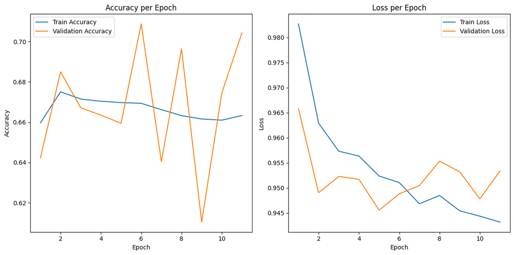

```python
# Step 10: Plot accuracy and loss
plt.figure(figsize=(12, 6))

# Accuracy plot
plt.subplot(1, 2, 1)
plt.plot(range(1, len(train_accuracies) + 1), train_accuracies, label="Train Accuracy")
plt.plot(range(1, len(val_accuracies) + 1), val_accuracies, label="Validation Accuracy")
plt.title("Accuracy per Epoch")
plt.xlabel("Epoch")
plt.ylabel("Accuracy")
plt.legend()

# Loss plot
plt.subplot(1, 2, 2)
plt.plot(range(1, len(train_losses) + 1), train_losses, label="Train Loss")
plt.plot(range(1, len(val_losses) + 1), val_losses, label="Validation Loss")
plt.title("Loss per Epoch")
plt.xlabel("Epoch")
plt.ylabel("Loss")
plt.legend()

plt.tight_layout()
plt.show()
```

#### 3.2.4 Assess CNN Model

The code following is to test the CNN model on test set with generating the confusion matrix and classification report.

Generally, the total test accuracy is 0.71. The performance is not bad in classes of "Master_Guild" and "No_Guild", but it is still not ideal in predicting class "Apprentice_Guild". This may be caused by imbalanced data structure (though I tried weighted cross-entropy loss to handle it) or insufficient capture of variables relations. Actually, I tried CNN with more convolutional layers or other optimizers, it turns out the result is the best we can achieve.

```
Test Accuracy: 0.7064
Confusion Matrix:
[[   34   208   175]
 [  195  2221   758]
 [  876  4488 13869]]
```

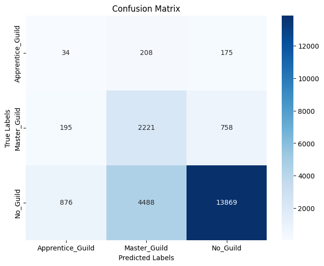

```
Classification Report:
                  precision    recall  f1-score   support

Apprentice_Guild       0.03      0.08      0.04       417
    Master_Guild       0.32      0.70      0.44      3174
        No_Guild       0.94      0.72      0.81     19233

        accuracy                           0.71     22824
       macro avg       0.43      0.50      0.43     22824
    weighted avg       0.83      0.71      0.75     22824
```

```python
from sklearn.metrics import confusion_matrix, classification_report
import seaborn as sns

# Step 11: Test the model
model.eval()
all_preds = []
all_labels = []
with torch.no_grad():
    for X_batch, y_batch in test_loader:
        X_batch, y_batch = X_batch.to(device), y_batch.to(device)
        outputs = model(X_batch)
        _, predicted = torch.max(outputs, 1)
        all_preds.extend(predicted.cpu().numpy())  # Collect predictions
        all_labels.extend(y_batch.cpu().numpy())  # Collect true labels

# Compute test accuracy
test_accuracy = np.mean(np.array(all_preds) == np.array(all_labels))
print(f"Test Accuracy: {test_accuracy:.4f}")

# Step 11: Print Confusion Matrix and Classification Report
conf_matrix = confusion_matrix(all_labels, all_preds)
print("Confusion Matrix:")
print(conf_matrix)

# Plot Confusion Matrix
plt.figure(figsize=(8, 6))
sns.heatmap(conf_matrix, annot=True, fmt='d', cmap='Blues', xticklabels=encoder.classes_, yticklabels=encoder.classes_)
plt.xlabel('Predicted Labels')
plt.ylabel('True Labels')
plt.title('Confusion Matrix')
plt.show()

# Classification Report
class_report = classification_report(all_labels, all_preds, target_names=encoder.classes_)
print("\nClassification Report:")
print(class_report)
```

## 4. Summary and Consideration

To sum up, here is the overview of our work:

Firstly, we pre-processed and explored the data structure, making the dataset more structured to be used and discovering correlations between variables.

Secondly, we applied logistic regression as the baseline model.

Thirdly, since the performance of logit model was not ideal, we attempted more complex models, including Random Forest Classifier and Convolutional Neural Network.

Finally, according to the results above, we make the model choice based on following considerations

1. Most importantly, the performace of the model, e.g. the total accuracy, the f1-score of each category, etc.
2. The cost of computing resource and running time of the model.
3. The complexity and interpretablity of the model.
4. The context and the purpose of the model.

The comparison among models are as follwoing:

Therefore, we choose CNN as the most suitable model.